# Bicep curls training

SWSRN

July 25, 2015

## Introduction

In this project, my goal will be to use data (Weight Lifting Exercise Dataset) from accelerometers on the belt, forearm, arm, and dumbbell of 6 participants. They were asked to perform barbell lifts correctly (class A) and incorrectly in 4 different ways (classes B, C, D and E). This data set is unusual for quantifying how well an activity is done, as well as the more commonly measured how much is done. The group Human Activity Recognition http://groupware.les.inf.puc-rio.br/har has kindly provided this data set (cite 3). An edited version of this data set was downloaded for training from https://d396qusza40orc.cloudfront.net/predmachlearn/pml-training.csv and for testing from https://d396qusza40orc.cloudfront.net/predmachlearn/pml-testing.csv.

## Reading Data

```r
 train <- read.csv('pml-training.csv', na.strings=c("#DIV/0!", "", "NA"),
                   stringsAsFactors=FALSE)
 test <- read.csv('pml-testing.csv', na.strings ="NA")
```

## Clean data and reduce number of columns

Initially $train$ has 19622 rows and 160 columns. There are a lot of columns with mostly blanks, or divide by zero or NA (treated as NA’s by $read.csv()$ above.) Except there are numbers in those columns when $train\$new\_window$ is equal to $yes$. These are only a few rows, don’t worry about them. (Deleting these rows made little difference in results.) Remove columns with any NA’s.

```r
train_noNA <- train[,colSums(is.na(train)) == 0]
test_noNA <- test[,colSums(is.na(test)) == 0]
```

Coerce the column classes to match in the two data sets train and test.

```r
  for (i in 1:ncol(test_noNA)) {
      if (names(test_noNA)[i] != names(train_noNA)[i] ) {#check col. aignment
          message( 'name ', i,'!!! ', names(test_noNA)[i], " != ",
            names(train_noNA)[i])
      }
      if (class(test_noNA[,i]) != class(train_noNA[,i]) ) {#convert type
          message( 'class ', i,' ', names(test_noNA)[i], ' ',
            class(test_noNA[,i]), "!=", class(train_noNA[,i]) )
          if (class(train_noNA[,i]) == 'character') {
              test_noNA[,i] <- as.character(test_noNA[,i])
          }
          if (class(test_noNA[,i]) == 'integer') {
              train_noNA[,i] <- as.integer(train_noNA[,i])
          }
      }
  }
```

```
## class 2 user_name factor!=character
## class 5 cvtd_timestamp factor!=character
## class 6 new_window factor!=character
## class 46 magnet_dumbbell_z integer!=numeric
## class 58 magnet_forearm_y integer!=numeric
## class 59 magnet_forearm_z integer!=numeric
## name 60!!! problem_id != classe
## class 60 problem_id integer!=character
```

Make the dates POSIX. Make the column $classe$ a factor variable.

```r
  train_noNA$cvtd_timestamp <- as.POSIXct(strptime(train_noNA$cvtd_timestamp, "%d/%m/%Y %H:%M"))
test_noNA$cvtd_timestamp <- as.POSIXct(strptime(test_noNA$cvtd_timestamp, "%d/%m/%Y %H:%M"))
train_noNA$classe <- as.factor(train_noNA$classe)
```

Remove additional columns which should not be relevant, i.e. non-numeric ($user\_name$, $new\_window$) or sequential($X$, $num\_window$) or time.

```r
  #names(train_noNA)[1:7]
  #class(train_noNA)
  #summary(train_noNA)
  train_noNA <- subset(train_noNA, select = -X)
  train_noNA <- subset(train_noNA, select = -user_name)
  train_noNA <- subset(train_noNA, select = -raw_timestamp_part_1)
  train_noNA <- subset(train_noNA, select = -raw_timestamp_part_2)
  train_noNA <- subset(train_noNA, select = -new_window)
  train_noNA <- subset(train_noNA, select = -cvtd_timestamp)
  train_noNA <- subset(train_noNA, select = -num_window)

  test_noNA <- subset(test_noNA, select = -X)
  test_noNA <- subset(test_noNA, select = -user_name)
  test_noNA <- subset(test_noNA, select = -raw_timestamp_part_1)
  test_noNA <- subset(test_noNA, select = -raw_timestamp_part_2)
  test_noNA <- subset(test_noNA, select = -new_window)
  test_noNA <- subset(test_noNA, select = -cvtd_timestamp)
  test_noNA <- subset(test_noNA, select = -num_window)

  #ncol(train_noNA)
  #names(train_noNA)
```

Note that if column “X” (1,2,3, …) is not removed, it will be the only column used by the random tree routine to fit to the class classe, because the file is sorted in order of A, B, C, D, E. The result will be an implausibly perfect fit!

The remaining variables:

vector variables

1. “roll_belt” “pitch_belt” “yaw_belt”
2. “gyros_belt_x” “gyros_belt_y” “gyros_belt_z”
3. “accel_belt_x” “accel_belt_y” “accel_belt_z”
4. “magnet_belt_x” “magnet_belt_y” “magnet_belt_z”
5. “roll_arm” “pitch_arm” “yaw_arm”
6. “gyros_arm_x” “gyros_arm_y” “gyros_arm_z”
7. “magnet_arm_x” “magnet_arm_y” “magnet_arm_z”
8. “roll_dumbbell” “pitch_dumbbell” “yaw_dumbbell”
9. “gyros_dumbbell_x” “gyros_dumbbell_y” “gyros_dumbbell_z”
10. “accel_dumbbell_x” “accel_dumbbell_y” “accel_dumbbell_z”
11. “magnet_dumbbell_x” “magnet_dumbbell_y” “magnet_dumbbell_z”
12. “roll_forearm” “pitch_forearm” “yaw_forearm”
13. “gyros_forearm_x” “gyros_forearm_y” “gyros_forearm_z”
14. “accel_forearm_x” “accel_forearm_y” “accel_forearm_z”
15. “magnet_forearm_x” “magnet_forearm_y” “magnet_forearm_z”

scalar variables

1. “total_accel_belt”
2. “total_accel_arm”
3. “total_accel_dumbbell”
4. “total_accel_forearm”
5. “classe” (Our result variable.)

There are numerous 3 vectors of the sort (roll, pitch, yaw) and (x,y,z). There are summary scalars of the sort acceleration. We chose to remove the 3-D x-y-z vectors for acceleration and assume that they will be well represented by the total accelerations (total_accel_belt, total_accel_arm, total_accel_dumbbell and total_accel_forearm.)

```r
train_noNA <- subset(train_noNA, select = -accel_belt_x)
train_noNA <- subset(train_noNA, select = -accel_belt_y)
train_noNA <- subset(train_noNA, select = -accel_belt_z)
train_noNA <- subset(train_noNA, select = -accel_arm_x)
train_noNA <- subset(train_noNA, select = -accel_arm_y)
train_noNA <- subset(train_noNA, select = -accel_arm_z)
train_noNA <- subset(train_noNA, select = -accel_dumbbell_x)
train_noNA <- subset(train_noNA, select = -accel_dumbbell_y)
train_noNA <- subset(train_noNA, select = -accel_dumbbell_z)
train_noNA <- subset(train_noNA, select = -accel_forearm_x)
train_noNA <- subset(train_noNA, select = -accel_forearm_y)
train_noNA <- subset(train_noNA, select = -accel_forearm_z)
```

## Check for correlations

Look at correlations ($symnum(cor(train_noNA))$) to see if additional columns should be eliminated. We discard “duplicate” columns at the 1.0 and 0.95 correlation levels, as these have little effect on the resulting accuracy.

```r
train_noNA <- subset(train_noNA, select = -roll_belt)  # to 1.0 correlation
train_noNA <- subset(train_noNA, select = -gyros_arm_x)# to 1.0 correlation
train_noNA <- subset(train_noNA, select = -gyros_dumbbell_x)# to 0.95 correlation
train_noNA <- subset(train_noNA, select = -gyros_dumbbell_z)# to 0.95 correlation
```

## Partition the Data.

Original file “pml-testing.csv” is too small to act as a test set (only 20 rows), seen around in this file as the matrix test_noNA. We have to split “pml-training.csv” (matrix train_noNA) into 70% “training” and 30% “testing” sets. Sorry for any confusion with the naming! “By default, createDataPartition does a stratified random split of the data.” (cite 2) This is good, since the data is sorted into long stretches of A’s, then B’s, etc.

```r
nr <- nrow(train_noNA)
indexTrain <- createDataPartition(y=train_noNA$classe,p=0.7, list=FALSE)
training <- train_noNA[indexTrain,]
testing <- train_noNA[-indexTrain,]
```

We do not select any special preprocessing.

```r
    #ncol(training)
    #preProc <- preProcess(training, method="pca", thresh=80)
    preProc <- training  # skip PCA for now.
    #ncol(preProc)
   #
```

```r
  set.seed(12345) # Should make results reproducible, but it doesn't. Naughty train().
  tuneLen = 57
  ecurl <- train(classe ~ ., data = preProc, method = 'rpart',
                   tuneLength = tuneLen)

  ecurl  # accuracy vs. complexity factor
```

```
## CART
##
## 13737 samples
##    36 predictor
##     5 classes: 'A', 'B', 'C', 'D', 'E'
##
## No pre-processing
## Resampling: Bootstrapped (25 reps)
##
## Summary of sample sizes: 13737, 13737, 13737, 13737, 13737, 13737, ...
##
## Resampling results across tuning parameters:
##
##   cp           Accuracy   Kappa      Accuracy SD  Kappa SD
##   0.001085003  0.8808540  0.8492132  0.009537772  0.01207030
##   0.001118910  0.8791355  0.8470318  0.010091274  0.01276924
##   0.001220629  0.8741583  0.8407266  0.010404739  0.01317296
##   0.001322348  0.8696684  0.8350361  0.011339719  0.01435252
##   0.001424067  0.8660921  0.8305116  0.011059922  0.01398661
##   0.001525786  0.8625939  0.8260728  0.011096681  0.01404242
##   0.001627505  0.8594769  0.8221037  0.010198019  0.01289416
##   0.001729224  0.8553365  0.8168581  0.010035058  0.01263050
##   0.001830943  0.8522367  0.8129559  0.010185987  0.01280033
##   0.001932662  0.8481686  0.8078164  0.008923042  0.01121950
##   0.002034381  0.8433763  0.8017161  0.009616024  0.01210722
##   0.002136100  0.8403938  0.7979522  0.010364174  0.01304447
##   0.002237819  0.8369607  0.7936318  0.010421257  0.01309219
##   0.002339538  0.8325711  0.7880685  0.009608944  0.01211139
##   0.002441257  0.8297570  0.7845054  0.010394060  0.01309671
##   0.002542976  0.8271648  0.7812273  0.010578594  0.01331584
##   0.002644695  0.8233028  0.7763662  0.010734706  0.01347792
##   0.002695555  0.8218472  0.7745183  0.011072188  0.01391836
##   0.002746414  0.8201766  0.7723869  0.010332279  0.01301941
##   0.002848133  0.8169554  0.7683313  0.010191694  0.01280363
##   0.002949853  0.8143870  0.7650662  0.011757800  0.01482560
##   0.003153291  0.8087807  0.7579492  0.011892688  0.01498567
##   0.003356729  0.8042734  0.7522312  0.011734823  0.01482389
##   0.003458448  0.8012604  0.7484137  0.012846560  0.01626398
##   0.003611026  0.7978328  0.7440567  0.012035850  0.01522795
##   0.003865324  0.7936912  0.7387999  0.013065084  0.01653196
```

[output cut: 19 more lines]

```
##   0.012206286  0.6661275  0.5766940  0.023689708  0.02969428
##   0.012816601  0.6611544  0.5704193  0.020977665  0.02625231
##   0.013223477  0.6555380  0.5634306  0.020348295  0.02558808
##   0.013579493  0.6492097  0.5555795  0.019564540  0.02446947
##   0.013935510  0.6467380  0.5524711  0.020041587  0.02506769
##   0.014647543  0.6381176  0.5419425  0.017854023  0.02197053
##   0.019733496  0.5751783  0.4581687  0.035222927  0.05157210
##   0.020496389  0.5624660  0.4408688  0.031291701  0.04725406
##   0.021157563  0.5458416  0.4174330  0.029495192  0.04683469
##   0.029498525  0.4937783  0.3429248  0.020443241  0.03450669
##   0.030312277  0.4919614  0.3404424  0.020880368  0.03536750
##   0.066320822  0.3889187  0.1732551  0.096701363  0.15678399
##
## Accuracy was used to select the optimal model using  the largest value.
## The final value used for the model was cp = 0.001085003.
```

We have used the train() option $tuneLength$, which defaults to 3. Values as high as about 90 “maximizes”" the training accuracy. However, with increasing values, the tree gets more and more branches and leaves and we suspect that we may be over-fitting. From a suggestion from community TA Ronny Restrepo, we investigated the “train” vs. “test” data sets. The accuracy will always be a bit lower for the test data set but the difference between the two will increase as the model overfits the train data (see table below) and the test data accuracy stagnates. We felt a good compromise is tuneLength = 57. The table below shows our exploration. For a fixed tuneLength, there is a fair amount of jiggle due to different random initializations within tune().

```
##    tuneLen diffAccur test_Accur train_Accur
## 1        7   -0.0100      0.607       0.606
## 2        7   -0.0100      0.608       0.606
## 3       15   -0.0200      0.694       0.702
## 4       30   -0.0100      0.774       0.778
## 5       37   -0.0153      0.781       0.789
## 6       45   -0.0254      0.839       0.859
## 7       52   -0.0208      0.856       0.871
## 8       57   -0.0283      0.897       0.921
## 9       60   -0.0240      0.908       0.927
## 10      63   -0.0342      0.898       0.928
## 11      67   -0.0354      0.900       0.931
## 12      75   -0.0358      0.910       0.942
## 13      75   -0.0409      0.902       0.939
## 14      90   -0.0416      0.903       0.941
```

[output cut: 21 more lines]

This plots the training accuracy as a function of the complexity parameter, with more complex trees on the left. The convergence point for this example is the left-most point.

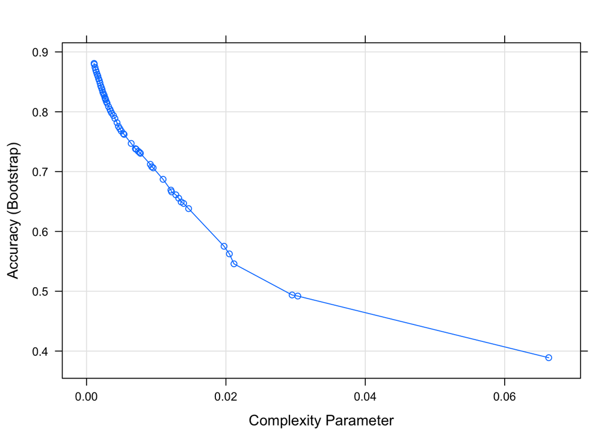

Below is our best decision tree in text format, which is rather long. Sorry! Due to the number of branches and leaves, the plot of the tree has been left out, since it is overwhelmed.

```
## n= 13737
##
## node), split, n, loss, yval, (yprob)
##       * denotes terminal node
##
##      1) root 13737 9831 A (0.28 0.19 0.17 0.16 0.18)
##        2) pitch_forearm< -33.55 1106    9 A (0.99 0.0081 0 0 0) *
##        3) pitch_forearm>=-33.55 12631 9822 A (0.22 0.21 0.19 0.18 0.2)
##          6) magnet_belt_y>=557.5 11586 8778 A (0.24 0.23 0.21 0.18 0.15)
##           12) magnet_dumbbell_y< 439.5 9697 6948 A (0.28 0.18 0.24 0.17 0.12)
##             24) roll_forearm< 120.5 6068 3611 A (0.4 0.18 0.18 0.15 0.092)
##               48) magnet_dumbbell_z< -27.5 2041  673 A (0.67 0.2 0.014 0.067 0.054)
##                 96) roll_forearm>=-136.5 1701  368 A (0.78 0.16 0.014 0.012 0.032)
##                  192) roll_forearm< 113.5 1572  277 A (0.82 0.12 0.015 0.011 0.034)
##                    384) magnet_dumbbell_y< 379.5 1287  101 A (0.92 0.061 0.0031 0.0016 0.012)
##                      768) gyros_dumbbell_y>=-0.525 1271   85 A (0.93 0.05 0.0031 0.0016 0.013)
##                       1536) gyros_belt_z< 0.16 1257   71 A (0.94 0.05 0.0032 0.0016 0.0016) *
##                       1537) gyros_belt_z>=0.16 14    0 E (0 0 0 0 1) *
##                      769) gyros_dumbbell_y< -0.525 16    0 B (0 1 0 0 0) *
##                    385) magnet_dumbbell_y>=379.5 285  176 A (0.38 0.36 0.07 0.053 0.13)
##                      770) pitch_belt>=17.45 53    0 B (0 1 0 0 0) *
##                      771) pitch_belt< 17.45 232  123 A (0.47 0.22 0.086 0.065 0.16)
##                       1542) roll_dumbbell>=-71.91276 156   51 A (0.67 0.23 0 0.096 0)
##                         3084) pitch_arm>=-39.55 139   34 A (0.76 0.14 0 0.11 0) *
##                         3085) pitch_arm< -39.55 17    0 B (0 1 0 0 0) *
##                       1543) roll_dumbbell< -71.91276 76   38 E (0.053 0.18 0.26 0 0.5)
##                         3086) pitch_belt>=13.65 38   18 C (0.11 0.37 0.53 0 0)
##                           6172) pitch_belt>=14.7 18    4 B (0.22 0.78 0 0 0) *
##                           6173) pitch_belt< 14.7 20    0 C (0 0 1 0 0) *
##                         3087) pitch_belt< 13.65 38    0 E (0 0 0 0 1) *
##                  193) roll_forearm>=113.5 129   42 B (0.29 0.67 0 0.031 0)
##                    386) magnet_belt_x>=25.5 18    0 A (1 0 0 0 0) *
##                    387) magnet_belt_x< 25.5 111   24 B (0.18 0.78 0 0.036 0) *
##                 97) roll_forearm< -136.5 340  211 B (0.1 0.38 0.012 0.34 0.16)
##                  194) gyros_arm_y>=0.985 121   32 B (0 0.74 0 0 0.26)
##                    388) yaw_belt< 2.4 92    3 B (0 0.97 0 0 0.033) *
##                    389) yaw_belt>=2.4 29    0 E (0 0 0 0 1) *
##                  195) gyros_arm_y< 0.985 219  103 D (0.16 0.18 0.018 0.53 0.11)
##                    390) yaw_arm< -71.6 30    1 B (0.033 0.97 0 0 0) *
##                    391) yaw_arm>=-71.6 189   73 D (0.18 0.058 0.021 0.61 0.13)
```

[output cut: 171 more lines]

```
##                  209) gyros_belt_z>=0.075 71    1 E (0 0.014 0 0 0.99) *
##                105) gyros_belt_z< -0.29 75    0 E (0 0 0 0 1) *
##               53) magnet_belt_z>=-292.5 167   23 E (0 0.11 0.024 0.006 0.86) *
##             27) total_accel_dumbbell< 5.5 581  206 D (0 0.13 0.0034 0.65 0.22)
##               54) pitch_belt>=13.2 462   87 D (0 0.17 0.0043 0.81 0.017)
##                108) yaw_belt< -2.825 73    0 B (0 1 0 0 0) *
##                109) yaw_belt>=-2.825 389   14 D (0 0.01 0.0051 0.96 0.021) *
##               55) pitch_belt< 13.2 119    0 E (0 0 0 0 1) *
##          7) magnet_belt_y< 557.5 1045  200 E (0.00096 0.012 0.0029 0.18 0.81)
##           14) magnet_dumbbell_z>=146.5 232   64 D (0 0.056 0.013 0.72 0.21)
##             28) magnet_belt_z< -444.5 170    3 D (0 0.018 0 0.98 0) *
##             29) magnet_belt_z>=-444.5 62   14 E (0 0.16 0.048 0.016 0.77) *
##           15) magnet_dumbbell_z< 146.5 813   16 E (0.0012 0 0 0.018 0.98)
##             30) yaw_dumbbell< -122.7058 13    1 D (0 0 0 0.92 0.077) *
##             31) yaw_dumbbell>=-122.7058 800    4 E (0.0013 0 0 0.0038 0.99) *
```

## Test on 30% reserved testing set

Frequency histogram of A,B, etc. of predicted testing results.

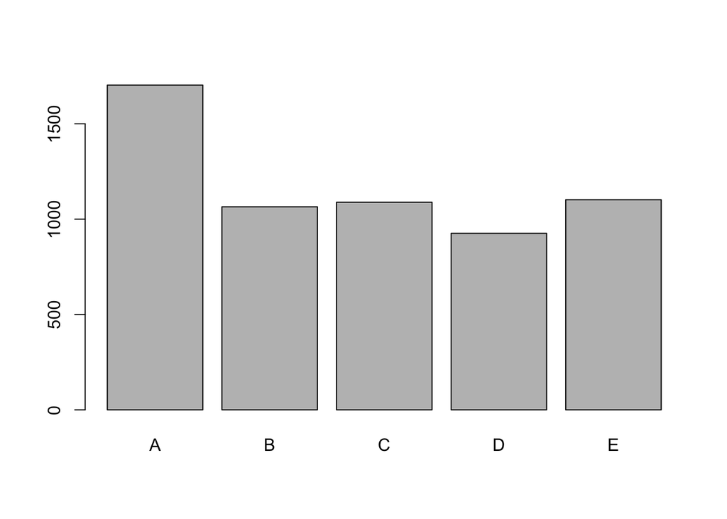

```r
  rpartPred_train <- predict(ecurl,training)
  rpartPred <- predict(ecurl,testing)
  #rpartPred <- predict(ecurl,testing,type="class")
  #rpartPred  # too big
  #str(rpartPred)

  plot(rpartPred)
```

## Results: Calculate accuracy (out of sample error) of test group by hand.

Out of 5885 test samples, the number of misidentified classes is only

```r
sum(rpartPred != testing$classe)
```

```
## [1] 653
```

```r
# df <- data.frame(testing$class, rpartPred)
```

giving an **accuracy rate (out of sample error) of 0.8890399.** But this is just a “by hand” estimate.

## Results: Confusion Matrix and Accuracy

Confusion matrix for testing and training sets. Shown is for testing data set.

```r
  confusionMatrix(rpartPred, testing$classe)
```

```
## Confusion Matrix and Statistics
##
##           Reference
## Prediction    A    B    C    D    E
##          A 1595   62    6   19   21
##          B   41  937   34   25   28
##          C    5   62  919   57   46
##          D   15   30   33  821   27
##          E   18   48   34   42  960
##
## Overall Statistics
##
##                Accuracy : 0.889
##                  95% CI : (0.8807, 0.897)
##     No Information Rate : 0.2845
##     P-Value [Acc > NIR] : < 2.2e-16
##
##                   Kappa : 0.8596
##  Mcnemar's Test P-Value : 0.0007313
##
## Statistics by Class:
##
##                      Class: A Class: B Class: C Class: D Class: E
## Sensitivity            0.9528   0.8227   0.8957   0.8517   0.8872
## Specificity            0.9744   0.9730   0.9650   0.9787   0.9704
## Pos Pred Value         0.9366   0.8798   0.8439   0.8866   0.8711
## Neg Pred Value         0.9811   0.9581   0.9777   0.9712   0.9745
## Prevalence             0.2845   0.1935   0.1743   0.1638   0.1839
## Detection Rate         0.2710   0.1592   0.1562   0.1395   0.1631
## Detection Prevalence   0.2894   0.1810   0.1850   0.1573   0.1873
## Balanced Accuracy      0.9636   0.8978   0.9304   0.9152   0.9288
```

The confusion matrix’s off diagonal elements show how many samples were mis-identified. The diagonal elements show how many were correctly identified. **The adjoining “Overall Statistics” also identifies the accuracy (0.8890399), kappa (0.859579) and the p-value (7.313300710^{-4}) for the test set.** In contrast, the training set has a “better” accuracy (0.9071122), kappa (0.8824533) and a p-value (2.440564210^{-13}).

The spread in the accuracies for the training and test sets is important for judging whether the model is over-fitting.

## Use 20 test cases file (from pml-testing.csv):

When repeatly run this markdown file, 80-90% of the values stay the same, reflecting the accuracy of the model used. For a fixed tuneLength, there is a fair amount of jiggle in the predictions due to different random initializations within tune(). Most of it is for certain test numbers. This table is not being included in the rMarkdown output.

```r
   rpartPred_20 <- predict(ecurl,test_noNA)
   #rpartPred_20   # Don't show prediction on the web
```

## Conclusions

The random tree model that we built has a 89% accuracy, which is a moderate success for first attempt. It is not as good as the 98% overall accuracy that the HAR group achieved with the same data (cite 3).

## References

1. http://static1.squarespace.com/static/51156277e4b0b8b2ffe11c00/t/53ad86e5e4b0b52e4e71cfab/1403881189332/Applied_Predictive_Modeling_in_R.pdf
2. https://cran.r-project.org/web/packages/caret/vignettes/caret.pdf
3. Velloso, E.; Bulling, A.; Gellersen, H.; Ugulino, W.; Fuks, H. Qualitative Activity Recognition of Weight Lifting Exercises. Proceedings of 4th International Conference in Cooperation with SIGCHI (Augmented Human ’13) . Stuttgart, Germany: ACM SIGCHI, 2013.

Read more: http://groupware.les.inf.puc-rio.br/har#wle_paper_section#ixzz3gjCVcSVT